Ficha del establecimiento

# Liceo Andrés Bello

RBD **9406**San MiguelEscuela o liceo

643estudiantes matriculadosCorte Agosto 2026

Mujeres0,0%0 est.

Hombres100,0%643 est.

Chilenos/as88,8%571 est.

Extranjeros/as11,2%72 est.

Actualizada al 05-10-2026

💻Ver ficha completaVersión para computador, con mapas y gráficos interactivos. Pesa varios MB: mejor ábrela con wifi.

🏛️Identificación

## Identificación del establecimiento

Los datos de contacto y las características básicas del establecimiento, tal como están registrados en el Ministerio de Educación. **Si algo está mal o falta, escríbenos** y lo corregimos en la próxima actualización.

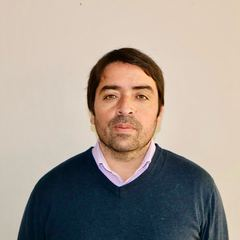

Director o directora

Jorge Oscar Muñoz Lopez

**Nombre**

Liceo Andrés Bello

**RBD**

9406

**Dirección**

Soto Aguilar 1241

**Comuna**

San Miguel

**Tipo**

Escuela o liceo

**Estado**

✅En funcionamiento

**Director/a**

Jorge Oscar Muñoz Lopez

**Correo**

liceoandresbello@slepsantarosa.cl

**Teléfono**

443144683

**Sitio web**

WWW.LICEOANDRESBELLO.CL

**Matrícula**

GRATUITO

**Sostenedor**

El sostenedor corresponde a una persona jurídica

**Orientación**

Orientación religiosa Laica

### Niveles que imparte

✓ 🎒 Enseñanza Básica Niños✓ 📘 Media Humanístico-Científica Jóvenes

### Vulnerabilidad del alumnado

Índice de vulnerabilidad (IVE)

59,9%

Lo calcula JUNAEB y sirve para asignar programas de apoyo.

0%100%

Este establecimientoPromedio de la comuna 62%

Prioritarios en Básica

78,0%

Estudiantes en 1ª, 2ª o 3ª prioridad.

Prioritarios en Media

72,1%

Estudiantes en 1ª, 2ª o 3ª prioridad.

**Un IVE más alto significa más necesidad de apoyo**, no peor calidad. Se usa para decidir a qué establecimientos llegan primero los programas de alimentación, salud y becas.

### Apoyos profesionales al aprendizaje

✓ 📚 Reforzamiento✓ 🧠 Psicólogo/a✓ 🧭 Orientador/a✓ 👩‍🏫 Profesor/a de educación especial✓ 🤝 Asistente social✓ 🗣️ Fonoaudiólogo/a🧩 Psicopedagogo/a🎓 Orientación vocacional➕ Otro

### Infraestructura y atención a la diversidad

✓ 📚 Biblioteca✓ 🔬 Laboratorio✓ 🏛️ Sala multiuso✓ 🌐 Computadores con internet✓ 🖥️ Sala de informática✓ 📽️ Sala audiovisual✓ 🏟️ Cancha deportiva✓ 🤾 Gimnasio✓ ♿ Accesibilidad NEE✓ ➕ Otra: ARTES💻 Computadores

✓ 👁️ Discapacidad visual✓ 👂 Discapacidad auditiva✓ 🧠 Discapacidad intelectual✓ 🧩 Trastorno del espectro autista✓ 💬 Trastornos de la comunicación✓ 📖 Dificultades de aprendizaje✓ 🎯 Déficit atencional✓ 📊 Funcionamiento intelectual limítrofe🦽 Discapacidad motora🗣️ Trastorno específico del lenguaje

Las etiquetas con ✓ son las que el establecimiento declaró en el directorio oficial; las grises no están marcadas.

### Jornada Escolar Completa (JEC)

Cursos con jornada completa

Cursos sin jornada completa

0

**Ver curso por curso**

| Grado | Cursos | Jornada |
| --- | --- | --- |
| 1° Medio | 3 | ✅ Con JEC |
| 2° Medio | 3 | ✅ Con JEC |
| 3° Medio | 3 | ✅ Con JEC |
| 4° Medio | 3 | ✅ Con JEC |
| 7° Básico | 2 | ✅ Con JEC |
| 8° Básico | 3 | ✅ Con JEC |

Con **Jornada Escolar Completa** los estudiantes tienen más horas de clases al día y almuerzan en el establecimiento.

### Idiomas

**Inglés en Enseñanza Básica**

Básico

**Inglés en Enseñanza Media**

Intermedio

### Certificación ambiental (SNCAE)

El establecimiento no tiene certificación del Sistema Nacional de Certificación Ambiental de Establecimientos Educacionales (SNCAE).

### Concentración de alumnado prioritario

Concentración 2026

45,4%

▼0,02 pts

Porcentaje de estudiantes prioritarios reconocidos por el Mineduc.

0%100%

Concentración del establecimiento

Concentración 2025

45,4%

Resolución exenta

2026

Observación del Ministerio: **Sin ACAP 2025-2026**.

La **concentración de prioritarios** define cuánta Subvención Escolar Preferencial (SEP) recibe el establecimiento. Sobre 60 % da acceso a la asignación por concentración.

### Requisitos para postular

✓ 🎂 Cumplir la edad mínima✓ 📄 Certificado de nacimiento✓ 📊 Certificado de notas✓ ✍️ Firmar el proyecto educativo✓ ⚖️ Firmar el reglamento de convivencia✓ 🎲 Sorteo📝 Informe de personalidad🏠 Ficha de protección social🧪 Test de intereses♿ Informe de necesidades educativas📋 Examen de ingreso👥 Entrevista con apoderados💍 Certificado de matrimonio⛪ Certificado de bautismo⛪ Certificado de matrimonio religioso💰 Pago de postulación➕ Otro

Desde el Sistema de Admisión Escolar, los establecimientos públicos **no pueden seleccionar** por rendimiento ni por antecedentes socioeconómicos. Estos son los antecedentes administrativos que el establecimiento declara pedir.

**Equipo del SLEP que acompaña al establecimiento**

**Asesor/a territorial**

DIEGO MENDOZA CISTERNAS

**Correo UTP**

utp.liceoandresbello@slepsantarosa.cl

**Correo Inspectoría**

inspectoria.liceoandresbello@slepsantarosa.cl

🏫Matrícula

## Matrícula y asistencia

Cuántos estudiantes tiene el establecimiento, quiénes son y cuántos días van efectivamente a clases. **La asistencia es el porcentaje de días que los estudiantes asistieron** sobre los días en que estuvieron matriculados.

Matrícula · Agosto 2026

643

▲1,3%

Variación desde el primer mes del año escolar.

1141.024

Este establecimientoPromedio del SLEP 333

Asistencia promedio

87,4%

Días asistidos sobre días matriculados.

-7,2%96,8%

Este añoPromedio de años anteriores 63,3%

Cursos

18

Niveles

2

Matrícula regular

643

Estudiantes en la modalidad regular del establecimiento.

Matrícula no regular

0

Modalidades de adultos, reingreso o validación de estudios.

Matrícula mes a mes · 2026

Cuántos estudiantes había registrados al cierre de cada mes.

Asistencia mes a mes · 2026

Porcentaje de días asistidos sobre los días en que el estudiante estuvo matriculado.

Matrícula año a año

Matrícula del último mes de cada año escolar.

### Quiénes estudian acá

Por género

Hombres · 643Mujeres · 0

Por origen

Chilenos/as · 571Extranjeros/as · 72Nacionalizados/as · 0

Nacionalidades presentes

Número de estudiantes por país de nacimiento declarado.

🇻🇪 Venezolana18

🇵🇪 Peruana7

🇨🇴 Colombiana6

❔ Sin información4

🇧🇴 Boliviana3

Otros6

Pueblos originarios

Estudiantes que declaran pertenecer a un pueblo originario.

🌿 Mapuche16

### Por nivel de enseñanza

Matrícula por nivel

🎒 Enseñanza Básica Niños119

📘 Media Humanístico-Científica Jóvenes524

Asistencia por nivel

La escala va de 0 % a 100 %.

🎒 Enseñanza Básica Niños86,4%

📘 Media Humanístico-Científica Jóvenes87,6%

### Asistencia por grupo

Asistencia por género

Promedio ponderado por el número de estudiantes de cada grupo.

Hombres87,4%

Mujeres0,0%

Asistencia por origen

Chilenos/as87,0%

Extranjeros/as90,5%

Asistencia por nacionalidad

Solo los seis grupos con más estudiantes.

🇨🇱 Chilena87,3%

🇻🇪 Venezolana89,6%

🇵🇪 Peruana93,9%

🇨🇴 Colombiana88,3%

❔ Sin información79,8%

🇧🇴 Boliviana66,7%

Asistencia por pueblo originario

🌿 Mapuche88,7%

**Ver el detalle curso por curso (18 cursos)**

| Curso | Matrícula | Asistencia % |
| --- | --- | --- |
| 7° Básico A | 26 | 88,6 |
| 7° Básico B | 24 | 85,4 |
| 8° Básico A | 36 | 88,6 |
| 8° Básico B | 33 | 83 |
| 1° Medio A | 40 | 89,6 |
| 1° Medio B | 39 | 88,8 |
| 1° Medio C | 39 | 87,8 |
| 1° Medio D | 39 | 91,8 |
| 1° Medio E | 39 | 79,8 |
| 2° Medio A | 40 | 87,8 |
| 2° Medio B | 40 | 85,4 |
| 2° Medio C | 41 | 87,4 |
| 3° Medio A | 31 | 90,5 |
| 3° Medio B | 32 | 87,5 |
| 3° Medio C | 36 | 89,6 |
| 4° Medio A | 36 | 87,7 |
| 4° Medio B | 37 | 88,9 |
| 4° Medio C | 35 | 83,9 |

**Ver la matrícula año a año, con su variación**

| Periodo | Matrícula | Variación | Cambio |
| --- | --- | --- | --- |
| 2026 | 643 | +55,0 | +9,4% |
| 2025 | 588 | −24,0 | −3,9% |
| 2024 | 612 | −15,0 | −2,4% |
| 2023 | 627 | +17,0 | +2,8% |
| 2022 | 610 | −31,0 | −4,8% |
| 2019 | 641 | −30,0 | −4,5% |
| 2018 | 671 | +18,0 | +2,8% |
| 2017 | 653 | +19,0 | +3,0% |
| 2016 | 634 | — | — |

**Ver la asistencia año a año, con su variación**

| Periodo | Asistencia | Variación | Cambio |
| --- | --- | --- | --- |
| 2026 | 87,4% | +6,2 pts | +7,6% |
| 2025 | 81,2% | +30,7 pts | +60,8% |
| 2024 | 50,5% | −25,5 pts | −33,6% |
| 2023 | 76,0% | −9,5 pts | −11,1% |
| 2022 | 85,5% | +85,5 pts | — |
| 2019 | 0,0% | −72,1 pts | −100,0% |
| 2018 | 72,1% | +20,2 pts | +38,9% |
| 2017 | 51,9% | −37,7 pts | −42,1% |
| 2016 | 89,6% | — | — |

La matrícula se cuenta al cierre de cada mes, así que los cambios durante el año reflejan traslados y retiros. Corte usado: **Agosto 2026**.

🤝Vida escolar

## Vida escolar y comunidad

Qué actividades ofrece el establecimiento fuera de las clases, cómo se organiza con las familias y quiénes representan a la comunidad. **Las etiquetas con ✓ son las que el establecimiento declaró** en el directorio oficial del Ministerio; las grises no están marcadas.

### Talleres y actividades para estudiantes

✓ 🧭 Orientación✓ 🤝 Convivencia✓ 🚫 Prevención drogas✓ ❤️ Educación sexual✓ 🌱 Medio ambiente✓ 🌟 Vida sana✓ 🫂 Acción social✝️ Pastoral➕ Otra

Actividades de formación: orientación, convivencia, prevención y vida sana.

✓ 📚 Literatura✓ 🎵 Música✓ 🎨 Artes plásticas✓ 💻 Taller TIC✓ 🎓 Preuniversitario✓ ➕ Otro: VARIOS🎭 Teatro✂️ Manualidades🩰 Danza o ballet

Talleres de arte, cultura y tecnología fuera del horario de clases.

✓ ⚽ Fútbol✓ 🥅 Baby fútbol✓ 🏐 Vóleibol✓ 🏀 Básquetbol✓ 🏓 Tenis de mesa✓ ♟️ Ajedrez✓ ➕ Otro: EDUCACIÓN FÍSICA OBLIGATORIA EN 3° Y 4° MEDIO🏃 Atletismo🏊 Natación🤸 Gimnasia🎾 Tenis

Disciplinas deportivas que ofrece el establecimiento.

### Trabajo con las familias

✓ 👪 Talleres de formación✓ 🎉 Actividades de integración✓ 📈 Perfeccionamiento➕ Otra

✓ 📒 Libreta de comunicaciones✓ 🌐 Web y redes sociales✓ 🗣️ Consejo escolar✓ 📄 Reuniones generales✓ 👥 Entrevistas individuales➕ Otro

Por dónde el establecimiento se comunica con apoderados y apoderadas.

### Organizaciones de la comunidad

**Centro de Padres**

Constituido

**Personalidad jurídica**

Vigente

**Última elección de directiva**

Vigente

**Centro de Estudiantes**

Constituido

**Representante del sostenedor en el Consejo Escolar**

Eiden Viera Pardo

**Acompañamiento del Consejo Escolar**

Solange Oñate Castillo

Para contactar al centro de padres o al centro de estudiantes, escribe al establecimiento: sus datos están más arriba.

El **Consejo Escolar** es la instancia donde se juntan dirección, docentes, asistentes, apoderados y estudiantes para conversar sobre la marcha del establecimiento.

### Normativa y conectividad

**Uso de uniforme**

Uniforme propio del establecimiento

**Tipo de conexión**

Fibra óptica

**Velocidad de internet**

Sin información

🧭Gestión

## Instrumentos de gestión: PEI y PME

El **PEI** dice quién quiere ser el establecimiento: su misión, su visión y sus sellos. El **PME** dice qué va a hacer este año para lograrlo, con responsables y presupuesto. Son los dos documentos que ordenan el trabajo.

### Proyecto Educativo Institucional (PEI)

**Misión**

El Liceo Andrés Bello brinda una educación humanista- científica, de calidad, diversificada, innovadora, pluralista y laica, para formar personas integrales cognitiva, afectiva, social y actitudinalmente, que valoren su historia, cultura y medio ambiente, en el marco de una sana convivencia con el fin de acceder a la educación superior.

**Visión**

“El año 2027 seremos reconocidos, en la comuna de San Miguel, como un liceo que forma personas que acceden a la educación superior, por el compromiso consigo mismos y sus procesos de aprendizaje. Personas que se caracterizan por un sello de respeto, tolerancia a la diversidad, en todas sus formas, el uso del diálogo para solucionar problemas, el pensamiento crítico para aprender y, el cuidado de la democracia y de su propio espacio.

### Énfasis declarados, en orden de prioridad

**1º**

Inclusivo

**2º**

Desarrollo integral

**3º**

Preparación PAES

### Documentos oficiales

[📘Proyecto Educativo](https://wwwfs.mineduc.cl/Archivos/infoescuelas/documentos/9406/ProyectoEducativo9406.pdf)[⚖️Reglamento de Convivencia](https://wwwfs.mineduc.cl/Archivos/infoescuelas/documentos/9406/ReglamentodeConvivencia9406.pdf)[📊Reglamento de Evaluación](https://wwwfs.mineduc.cl/Archivos/infoescuelas/documentos/9406/ReglamentoDeEvaluacion9406.pdf)

### Plan de Mejoramiento Educativo (PME)

Acciones comprometidas

44

Inversión total del plan

$ 174.843.769

Dimensiones cubiertas

4

Acciones por dimensión

Las cuatro dimensiones del PME: gestión pedagógica, liderazgo, convivencia y recursos.

Gestión Pedagógica15

Convivencia Escolar12

Gestión de Recursos11

Liderazgo6

Quién lidera las acciones

Los cinco responsables con más acciones a cargo.

Director19

Equipo UTP6

Jefe técnico4

Coordinador PAA2

Encargado de convivencia2

De dónde sale el financiamiento

Monto comprometido por fuente de recursos.

sep$ 159.843.769

pro retencion$ 15.000.000

**Ver las 44 acciones del plan**

| Acción | Dimensión | Responsable | Monto |
| --- | --- | --- | --- |
| Plan de Acompañamiento (Decreto 67) | Gestión Pedagógica | Coordinador PAA | $ 0 |
| Servicio de Plataforma Educativa | Gestión Pedagógica | Director | $ 3.941.817 |
| Alerta temprana desempeño académico de estudiantes | Gestión Pedagógica | Equipo UTP | $ 0 |
| Medición de aprendizajes de los estudiantes | Gestión Pedagógica | Equipo UTP | $ 0 |
| Análisis de resultados | Gestión Pedagógica | Equipo de UTP | $ 0 |
| Análisis de datos | Gestión Pedagógica | Equipo Directivo | $ 0 |
| Proceso integral de formación docente para la gestión basada en análisis de datos. | Gestión Pedagógica | Equipo de gestión | $ 0 |
| Planificaciones que incorporan estrategias para el desarrollo de habilidades cognitivas de nivel sup | Gestión Pedagógica | UTP | $ 0 |
| Prácticas pedagógicas innovadoras | Gestión Pedagógica | UTP - Jefes de Departamento - Coordinación de Innovación | $ 0 |
| PAD (Plan de Acompañamiento Docente) | Gestión Pedagógica | Equipo de Gestión | $ 0 |
| Vinculación PIE y familia de estudiantes | Gestión Pedagógica | Coordinadora PIE | $ 0 |
| Sensibilización y concientización en el contexto de las NEE | Gestión Pedagógica | Coordinador PAA | $ 0 |
| Fortalecimiento de la gestión pedagógica de los Departamentos Académicos | Gestión Pedagógica | Equipo UTP | $ 0 |
| Plan Integral de Coordinaciones: una formación andresbellina articulada | Gestión Pedagógica | Equipo UTP | $ 0 |
| Acompañamiento pedagógico innovador para el monitoreo y mejora del aprendizaje de los estudiantes. | Gestión Pedagógica | Jefe técnico | $ 0 |
| Contratación de Profesionales para fortalecer la gestión de soporte para los procesos educativos de | Liderazgo | Docente aula | $ 13.161.135 |
| Monitoreo PME | Liderazgo | Director | $ 0 |
| Análisis de acciones PME | Liderazgo | Director | $ 0 |
| Monitoreo de resultados de eficiencia interna | Liderazgo | Docente apoyo PME | $ 0 |
| Comunidad andresbellina informada | Liderazgo | Director | $ 0 |
| Contratación de profesionales en distintas áreas del EA | Liderazgo | Director | $ 118.450.217 |
| Asistencia y resguardo de las trayectorias educativas (Dupla Psicosocial) | Convivencia Escolar | Director | $ 0 |
| Servicio de transporte escolar para salidas pedagógicas y/o actividades extraescolares | Convivencia Escolar | Director | $ 3.660.000 |
| Profesional de apoyo en primeros auxilios y de atención a las necesidades educativas | Convivencia Escolar | Director | $ 0 |
| Talleres Convivencia Escolar | Convivencia Escolar | Encargado de convivencia | $ 200.000 |
| Fortalecimiento de la identidad andresbellina mediante celebraciones institucionales y temáticas | Convivencia Escolar | Equipo de gestión | $ 4.000.000 |
| Ceremonia de investidura | Convivencia Escolar | Director | $ 0 |
| Apadrinamientos novatos andresbellinos | Convivencia Escolar | Encargado de convivencia | $ 0 |
| Fiesta de la chilenidad, alianza familia escuela | Convivencia Escolar | Director | $ 0 |
| Ceremonia de Licenciatura IV° Medios | Convivencia Escolar | Director | $ 0 |
| Ceremonia de transición de octavo básico a enseñanza media | Convivencia Escolar | Director | $ 0 |
| Cierre de ciclo, etapa de trayectoria andresbellina | Convivencia Escolar | Director | $ 0 |
| Acompañamiento a los estudiantes en el ámbito convivencial y socioafectivo | Convivencia Escolar | Equipo Convivencia Escolar | $ 0 |
| Servicio de equipos multicopiadores para el Apoyo Pedagógico | Gestión de Recursos | Director | $ 268.665 |
| Adquisición de Material Escolar para el Apoyo al Aprendizaje | Gestión de Recursos | Jefe técnico | $ 2.131.401 |
| Contratación de Docentes y/o Asistentes de la Educación para Apoyo Pedagógico | Gestión de Recursos | Director | $ 0 |
| Implementar un sistema interno de registro de recepción, entrega y uso de recursos, garantizando su | Gestión de Recursos | Director | $ 0 |
| Espacio de protección para favorecer el bienestar emocional, conductual y sensorial de los estdantes | Gestión de Recursos | Director | $ 4.251.420 |
| Sala de Bienestar Docente y Asistentes | Gestión de Recursos | Director | $ 0 |
| Taller de Audiovisual y Revista LAB | Gestión de Recursos | Equipo UTP | $ 1.823.649 |
| Modernización Tecnológica para Evaluaciones y Recursos Audiovisuales | Gestión de Recursos | Equipo UTP | $ 4.365.666 |
| Software de apoyo pedagógico | Gestión de Recursos | Director | $ 526.389 |
| Adquisición de material didáctico y literario para el desarrollo de habilidades | Gestión de Recursos | Jefe técnico | $ 3.063.410 |
| Talleres para el desarrollo integral y la permanencia escolar de los estudiantes | Gestión de Recursos | Jefe técnico | $ 15.000.000 |

**Ver plazos y estado de ejecución de cada acción**

| Acción | Inicio | Término | Nivel de ejecución |
| --- | --- | --- | --- |
| Plan de Acompañamiento (Decreto 67) | 08/3/2025 | 08/12/2025 | No Implementado (0%) |
| Servicio de Plataforma Educativa | 01/3/2025 | 31/12/2025 | Implementación avanzada (75% a 99%) |
| Alerta temprana desempeño académico de estudiantes | 05/3/2025 | 31/12/2025 | Implementación avanzada (75% a 99%) |
| Medición de aprendizajes de los estudiantes | 03/3/2025 | 29/12/2025 | Implementación avanzada (75% a 99%) |
| Análisis de resultados | 03/3/2025 | 29/12/2025 | No Implementado (0%) |
| Análisis de datos | 03/3/2025 | 30/12/2025 | No Implementado (0%) |
| Proceso integral de formación docente para la gestión basada en análisis de datos. | 03/3/2025 | 30/12/2025 | Implementado de manera adecuada (50% a 74%) |
| Planificaciones que incorporan estrategias para el desarrollo de habilidades cognitivas de nivel sup | 05/3/2025 | 31/12/2025 | No Implementado (0%) |
| Prácticas pedagógicas innovadoras | 06/3/2025 | 07/12/2025 | No Implementado (0%) |
| PAD (Plan de Acompañamiento Docente) | 05/3/2025 | 05/12/2025 | No Implementado (0%) |
| Vinculación PIE y familia de estudiantes | 05/3/2025 | 12/12/2025 | Implementación avanzada (75% a 99%) |
| Sensibilización y concientización en el contexto de las NEE | 05/3/2025 | 30/12/2025 | Implementación avanzada (75% a 99%) |
| Fortalecimiento de la gestión pedagógica de los Departamentos Académicos | 06/3/2025 | 31/12/2025 | Implementación avanzada (75% a 99%) |
| Plan Integral de Coordinaciones: una formación andresbellina articulada | 05/3/2025 | 31/12/2025 | Implementación avanzada (75% a 99%) |
| Acompañamiento pedagógico innovador para el monitoreo y mejora del aprendizaje de los estudiantes. | 03/3/2025 | 31/12/2025 | Implementación avanzada (75% a 99%) |
| Contratación de Profesionales para fortalecer la gestión de soporte para los procesos educativos de | 06/3/2025 | 31/12/2025 | Implementado (100%) |
| Monitoreo PME | 05/3/2025 | 12/12/2025 | Implementación avanzada (75% a 99%) |
| Análisis de acciones PME | 05/3/2025 | 12/12/2025 | No Implementado (0%) |
| Monitoreo de resultados de eficiencia interna | 03/3/2025 | 30/12/2025 | Implementación avanzada (75% a 99%) |
| Comunidad andresbellina informada | 03/3/2025 | 30/12/2025 | Implementación avanzada (75% a 99%) |
| Contratación de profesionales en distintas áreas del EA | 01/3/2025 | 31/12/2025 | Implementado (100%) |
| Asistencia y resguardo de las trayectorias educativas (Dupla Psicosocial) | 05/3/2025 | 30/12/2025 | No Implementado (0%) |
| Servicio de transporte escolar para salidas pedagógicas y/o actividades extraescolares | 02/5/2025 | 31/12/2025 | Implementado (100%) |
| Profesional de apoyo en primeros auxilios y de atención a las necesidades educativas | 05/3/2025 | 30/12/2025 | Implementado (100%) |
| Talleres Convivencia Escolar | 01/4/2025 | 12/12/2025 | Implementación avanzada (75% a 99%) |
| Fortalecimiento de la identidad andresbellina mediante celebraciones institucionales y temáticas | 03/3/2025 | 31/12/2025 | Implementación avanzada (75% a 99%) |
| Ceremonia de investidura | 03/3/2025 | 30/5/2025 | No Implementado (0%) |
| Apadrinamientos novatos andresbellinos | 03/3/2025 | 29/4/2025 | No Implementado (0%) |
| Fiesta de la chilenidad, alianza familia escuela | 01/7/2025 | 02/10/2025 | No Implementado (0%) |
| Ceremonia de Licenciatura IV° Medios | 03/6/2025 | 23/12/2025 | No Implementado (0%) |
| Ceremonia de transición de octavo básico a enseñanza media | 02/8/2025 | 20/12/2025 | No Implementado (0%) |
| Cierre de ciclo, etapa de trayectoria andresbellina | 03/6/2025 | 13/12/2025 | No Implementado (0%) |
| Acompañamiento a los estudiantes en el ámbito convivencial y socioafectivo | 05/3/2025 | 31/12/2025 | Implementación avanzada (75% a 99%) |
| Servicio de equipos multicopiadores para el Apoyo Pedagógico | 04/3/2025 | 31/12/2025 | Implementado (100%) |
| Adquisición de Material Escolar para el Apoyo al Aprendizaje | 04/3/2025 | 31/12/2025 | Implementación avanzada (75% a 99%) |
| Contratación de Docentes y/o Asistentes de la Educación para Apoyo Pedagógico | 04/3/2025 | 31/12/2025 | No Implementado (0%) |
| Implementar un sistema interno de registro de recepción, entrega y uso de recursos, garantizando su | 03/3/2025 | 30/12/2025 | Implementación avanzada (75% a 99%) |
| Espacio de protección para favorecer el bienestar emocional, conductual y sensorial de los estdantes | 12/5/2025 | 31/12/2025 | Implementado inicialmente (1% a 24%) |
| Sala de Bienestar Docente y Asistentes | 12/5/2025 | 12/12/2025 | No Implementado (0%) |
| Taller de Audiovisual y Revista LAB | 12/5/2025 | 31/12/2025 | Implementación avanzada (75% a 99%) |
| Modernización Tecnológica para Evaluaciones y Recursos Audiovisuales | 12/5/2025 | 31/12/2025 | Implementado inicialmente (1% a 24%) |
| Software de apoyo pedagógico | 12/5/2025 | 30/12/2025 | No Implementado (0%) |
| Adquisición de material didáctico y literario para el desarrollo de habilidades | 03/6/2025 | 30/12/2025 | Implementado de manera adecuada (50% a 74%) |
| Talleres para el desarrollo integral y la permanencia escolar de los estudiantes | 03/6/2025 | 30/12/2025 | Implementación avanzada (75% a 99%) |

**Ver estrategia, programa y medios de verificación**

[output not shown]

**Ver la descripción completa y la justificación de cada acción**

| Acción | Qué se hace | Por qué |
| --- | --- | --- |
| Plan de Acompañamiento (Decreto 67) | Ejecución de Plan de Acompañamiento y contratación o designación de profesional con el objetivo de apoyar a estudiantes que presentan mayores brechas de aprendizaje con el propósito de generar un impa… | Acción se está implementando, se incluye nueva acción en liderazgo que incluye ítem de gasto RRHH |
| Servicio de Plataforma Educativa | La plataforma educativa es una herramienta digital que facilita la planificación, implementación y seguimiento con un enfoque pedagógico. Su propósito es fortalecer la gestión curricular y didáctica, … | El nivel de implementación está dentro del curso adecuado en relación a las fechas programadas. |
| Alerta temprana desempeño académico de estudiantes | Consolidar un sistema de alerta temprana de desempeño académico, implementando apoyos diferenciados para estudiantes en riesgo. | El nivel de implementación está dentro del curso adecuado en relación a las fechas programadas. |
| Medición de aprendizajes de los estudiantes | Aplicar diagnósticos de aprendizajes en asignaturas fundamentales al inicio, mitad y término del año escolar. | El nivel de implementación está dentro del curso adecuado en relación a las fechas programadas. |
| Análisis de resultados | Implementar jornadas de análisis de resultados académicos y de indicadores de desarrollo personal y social, con participación de todos los estamentos en el Consejo de Técnico, Reunión de Departamentos… | Es necesario integrar acciones en una sola, algunas respondían a un mismo objetivo |
| Análisis de datos | Capacitar a los docentes y equipos técnicos en el uso de datos para la toma de decisiones pedagógicas y de gestión institucional. | Es necesario integrar acciones en una sola, algunas respondían a un mismo objetivo. |
| Proceso integral de formación docente para la gestión basada en análisis de datos. | Proceso formativo integral para docentes y equipos técnicos que combina el uso estratégico de datos para la toma de decisiones pedagógicas y de gestión institucional, con la mejora de planificaciones … | El nivel de implementación está dentro del curso adecuado en relación a las fechas programadas. |
| Planificaciones que incorporan estrategias para el desarrollo de habilidades cognitivas de nivel sup | Actualizar y perfeccionar las planificaciones de asignaturas fundamentales incorporando habilidades cognitivas de orden superior, estrategias inclusivas y metodologías innovadoras. | Es necesario integrar acciones en una sola, algunas respondían a un mismo objetivo. |
| Prácticas pedagógicas innovadoras | Implementar prácticas pedagógicas innovadoras basadas en el uso de TICs, aprendizaje profundo y estrategias inclusivas en las asignaturas fundamentales. | Es necesario integrar acciones en una sola, algunas respondían a un mismo objetivo. |
| PAD (Plan de Acompañamiento Docente) | Realizar ciclos de observación, acompañamiento, monitoreo y retroalimentación de prácticas pedagógicas en el aula con enfoque en habilidades de nivel superior. | Es necesario integrar acciones en una sola, algunas respondían a un mismo objetivo. |
| Vinculación PIE y familia de estudiantes | Realizar talleres semestrales para apoderados de estudiantes PIE sobre estrategias de apoyo en el hogar, comprensión del Decreto 83 y estrategias de inclusión familiar. | El nivel de implementación está dentro del curso adecuado en relación a las fechas programadas. |
| Sensibilización y concientización en el contexto de las NEE | Capacitar al equipo docente y PIE en temáticas del Decreto 83 (adecuaciones curriculares), Decreto 67 (evaluación) y Decreto 170 (diagnóstico y criterios de NEE) para fortalecer el enfoque inclusivo d… | El nivel de implementación está dentro del curso adecuado en relación a las fechas programadas. |
| Fortalecimiento de la gestión pedagógica de los Departamentos Académicos | Fortalecer el trabajo de los departamentos académicos a través del acompañamiento desde UTP en camina a elaborar un currículum andresbellino. Además, la incorporación de una educadora diferencial como… | El nivel de implementación está dentro del curso adecuado en relación a las fechas programadas. |
| Plan Integral de Coordinaciones: una formación andresbellina articulada | Diseñar e implementar un plan de articulación de coordinaciones institucionales: Coordinación de Deportes, cultura y medioambiente; Coordinación de género, interculturalidad, inclusión, migraciones y … | El nivel de implementación está dentro del curso adecuado en relación a las fechas programadas. |
| Acompañamiento pedagógico innovador para el monitoreo y mejora del aprendizaje de los estudiantes. | Desarrollar un proceso integral que combine la evaluación constante del aprendizaje de los estudiantes con el análisis profundo de los resultados obtenidos, para identificar oportunamente las necesida… | El nivel de implementación está dentro del curso adecuado en relación a las fechas programadas. |
| Contratación de Profesionales para fortalecer la gestión de soporte para los procesos educativos de | Contratación de profesionales especializados en distintas áreas para fortalecer la gestión de los procesos educativos en los establecimientos educacionales, optimizando la planificación, seguimiento y… | El nivel de implementación está dentro del curso adecuado en relación a las fechas programadas. |
| Monitoreo PME | Diseñar e implementar un plan anual de monitoreo, evaluación y retroalimentación del PME en conjunto con los equipos de trabajo. | El nivel de implementación está dentro del curso adecuado en relación a las fechas programadas. |
| Análisis de acciones PME | Liderar reuniones cada dos meses de análisis de resultados de avances del PME, promoviendo la toma de decisiones basadas en evidencia. | Es necesario integrar acciones en una sola, algunas respondían a un mismo objetivo. |
| Monitoreo de resultados de eficiencia interna | Elaborar informes cada dos meses de avance de los indicadores de eficiencia interna (promoción, repitencia, deserción) y de desempeño académico. | El nivel de implementación está dentro del curso adecuado en relación a las fechas programadas. |
| Comunidad andresbellina informada | Difundir resultados de indicadores de desempeño y avances del PME a toda la comunidad educativa mediante boletines informativos y reuniones | El nivel de implementación está dentro del curso adecuado en relación a las fechas programadas. |
| Contratación de profesionales en distintas áreas del EA | Contratación de profesionales que desarrollen acciones en diversas áreas para propiciar el desarrollo académico y bienestar de los estudiantes | El nivel de implementación está dentro del curso adecuado en relación a las fechas programadas. |
| Asistencia y resguardo de las trayectorias educativas (Dupla Psicosocial) | Contratación de especialistas del área psicosocial, como trabajadores sociales, psicólogos y coordinadores, para fortalecer el acompañamiento integral de los y las estudiantes y garantizar su continui… | Acción se está implementando, se incluye nueva acción en liderazgo que incluye ítem de gasto RRHH |
| Servicio de transporte escolar para salidas pedagógicas y/o actividades extraescolares | El servicio de transporte escolar para salidas pedagógicas y actividades extraescolares facilita el acceso de los y las estudiantes a experiencias de aprendizaje fuera del aula, enriqueciendo su forma… | El nivel de implementación está dentro del curso adecuado en relación a las fechas programadas. |
| Profesional de apoyo en primeros auxilios y de atención a las necesidades educativas | La incorporación de un TENS en los establecimientos educativos permite brindar atención oportuna en primeros auxilios ante accidentes o emergencias que puedan ocurrir durante la jornada escolar. Este … | El nivel de implementación está dentro del curso adecuado en relación a las fechas programadas. |
| Talleres Convivencia Escolar | Realizar talleres y campañas de formación en valores, buen trato, respeto y sentido de pertenencia para toda la comunidad escolar. | El nivel de implementación está dentro del curso adecuado en relación a las fechas programadas. |
| Fortalecimiento de la identidad andresbellina mediante celebraciones institucionales y temáticas | Celebraciones institucionales y temáticas que promuevan la identidad y sellos andresbellinos, la sana convivencia y el sentido de pertenencia, incluyendo ceremonias institucionales (investidura, anive… | El nivel de implementación está dentro del curso adecuado en relación a las fechas programadas. |
| Ceremonia de investidura | Desarrollar ceremonia de investidura para estudiantes nuevos (entrega de himno, insignia y corbata) fortaleciendo identidad institucional andresbellina | Es necesario integrar acciones en una sola, algunas respondían a un mismo objetivo. |
| Apadrinamientos novatos andresbellinos | Mejorar la acción de apadrinamiento de estudiantes de tercero y cuarto medio a los estudiantes de séptimo básico para fortalecer la pertenencia y el apoyo intergeneracional | Es necesario integrar acciones en una sola, algunas respondían a un mismo objetivo. |
| Fiesta de la chilenidad, alianza familia escuela | Realizar la Fiesta de la Chilenidad integrando a toda la comunidad escolar en torno a tradiciones nacionales y fortalecimiento del sentido de identidad cultural. | Es necesario integrar acciones en una sola, algunas respondían a un mismo objetivo. |
| Ceremonia de Licenciatura IV° Medios | Organizar la ceremonia de licenciatura de los cuartos medios, destacando su trayectoria educativa e identidad andresbellina como cierre de un proceso de trayectoria educativa como lo expresa una estro… | Es necesario integrar acciones en una sola, algunas respondían a un mismo objetivo. |
| Ceremonia de transición de octavo básico a enseñanza media | Realizar la ceremonia de transición de octavo básico a enseñanza media, fortaleciendo su sentido de proyección y continuidad escolar. Iniciando una nueva etapa, como versa en nuestro himno institucion… | Es necesario integrar acciones en una sola, algunas respondían a un mismo objetivo. |
| Cierre de ciclo, etapa de trayectoria andresbellina | Ejecutar una actividad final de ciclo para cuartos medios que potencie su sentido de cierre de etapa y pertenencia institucional, como versa nuestro himno institucional: Tú nos das el vigor que necesi… | Sin justificación |
| Acompañamiento a los estudiantes en el ámbito convivencial y socioafectivo | Acompañar y apoyar a estudiantes con conductas disruptivas o víctimas de situaciones convivenciales, mediante un plan de intervención individual, acciones de contención emocional y seguimiento coordin… | El nivel de implementación está dentro del curso adecuado en relación a las fechas programadas. |
| Servicio de equipos multicopiadores para el Apoyo Pedagógico | Contratación de un servicio de multicopiado para la impresión de material didáctico de calidad, con el objetivo de fortalecer los procesos de enseñanza y aprendizaje de los estudiantes. Este servicio … | El nivel de implementación está dentro del curso adecuado en relación a las fechas programadas. |
| Adquisición de Material Escolar para el Apoyo al Aprendizaje | Adquisición de material escolar e insumos de material pedagógico para garantizar que todos los estudiantes cuenten con los recursos necesarios para su desarrollo académico, fortaleciendo el acceso equ… | El nivel de implementación está dentro del curso adecuado en relación a las fechas programadas. |
| Contratación de Docentes y/o Asistentes de la Educación para Apoyo Pedagógico | La contratación de docentes y asistentes de la educación tiene como objetivo fortalecer y apoyar los procesos pedagógicos, brindando un acompañamiento especializado a los estudiantes. Estos profesiona… | Acción se está implementando, se incluye nueva acción en liderazgo que incluye ítem de gasto RRHH |
| Implementar un sistema interno de registro de recepción, entrega y uso de recursos, garantizando su | Personal con horas para gestionar Administración de Recursos, planilla electrónica, plataforma digital (Google Drive) | El nivel de implementación está dentro del curso adecuado en relación a las fechas programadas. |
| Espacio de protección para favorecer el bienestar emocional, conductual y sensorial de los estdantes | La sala de reconexión, contención y regulación es una espacio seguro de de protección para contener a los estudiantes que presentan crisis o desregulaciones durante la jornada académica con la asisten… | El nivel de implementación está dentro del curso adecuado en relación a las fechas programadas. |
| Sala de Bienestar Docente y Asistentes | Habilitación de un espacio de descanso y autocuidado con mobiliario adecuado para docentes y asistentes de la educación. | Acción no se realizará |
| Taller de Audiovisual y Revista LAB | Equipar un espacio para producción audiovisual y desarrollo de habilidades comunicativas mediante una revista estudiantil. | El nivel de implementación está dentro del curso adecuado en relación a las fechas programadas. |
| Modernización Tecnológica para Evaluaciones y Recursos Audiovisuales | Adquisición de data, impresora carro ancho, scanner lector corrector de pruebas, cámara fotográfica y telón, para fortalecer procesos pedagógicos | Los recursos comprometidos para la implementación de la actividad llegaron a destiempo. |
| Software de apoyo pedagógico | Software de simulación en Matemática y Ciencias para ser utilizado en las asignaturas del plan común y de profundización | A la fecha no han llegado los insumos necesarios. |
| Adquisición de material didáctico y literario para el desarrollo de habilidades | Compra de recursos didácticos y obras literarias que estimulen el pensamiento crítico, la comprensión profunda y la argumentación en los estudiantes. Esta acción busca fortalecer habilidades de anális… | El nivel de implementación está dentro del curso adecuado en relación a las fechas programadas. |
| Talleres para el desarrollo integral y la permanencia escolar de los estudiantes | Talleres ACLE / Academias deportivos, musicales, artísticos y académicos, con el fin de potenciar habilidades, intereses y talentos de los estudiantes. Esta acción promueve su participación activa, se… | El nivel de implementación está dentro del curso adecuado en relación a las fechas programadas. |

🏆SNED

## SNED · Sistema Nacional de Evaluación del Desempeño

El SNED evalúa cada dos años el desempeño de los establecimientos municipales y particulares subvencionados. Mira **seis factores**: efectividad, superación, igualdad de oportunidades, iniciativa, integración y mejoramiento.

⚪No seleccionado

Índice SNED del establecimiento

Va de 0 a 100 y resume los seis factores que evalúa el sistema.

Los seis factores, uno por uno

Cada factor va de 0 a 100. Los de arriba pesan más en el índice final.

Efectividad51,5%

Superación28,7%

Igualdad de oportunidades95,1%

Iniciativa80,0%

Integración69,6%

Mejoramiento95,9%

**¿Cuánto pesa cada factor?**

| Factor | Puntaje | Peso en el índice (%) |
| --- | --- | --- |
| Efectividad | 51,5 | 37 |
| Superación | 28,7 | 28 |
| Igualdad de oportunidades | 95,1 | 22 |
| Iniciativa | 80 | 6 |
| Integración | 69,6 | 5 |
| Mejoramiento | 95,9 | 2 |

El SNED premia con un bono a los equipos de los establecimientos con mejor desempeño dentro de un grupo de escuelas parecidas. **No es una nota**: compara con establecimientos de condiciones similares, no con todo Chile.

💼Ocupación

## Ocupación de cupos

Cuántos de los cupos que el establecimiento ofreció están efectivamente ocupados. **Se calcula dividiendo la matrícula actual por los cupos declarados** en el Sistema de Admisión Escolar (SAE).

⚠️Con cupos disponibles

Ocupación de los cupos

La marca gris señala el 100 %: por sobre esa línea hay más estudiantes que cupos declarados.

Cupos declarados (SAE)

Matrícula al corte

643

Agosto 2026

Cupos libres

Cupos que quedan sin usar.

Vacantes en el curso de ingreso

90

**Ver los cupos declarados por grado**

| Grado | Cursos | Cupos |
| --- | --- | --- |
| 1° Medio | 3 | 120 |
| 2° Medio | 3 | 120 |
| 3° Medio | 3 | 120 |
| 4° Medio | 3 | 120 |
| 7° Básico | 2 | 80 |
| 8° Básico | 3 | 120 |

La ocupación compara la **matrícula efectiva** con los **cupos que el establecimiento declaró** en el Sistema de Admisión Escolar. Una ocupación baja no siempre es mala: puede ser espacio para crecer.

♿PIE

## Programa de Integración Escolar (PIE)

Cuántos estudiantes reciben apoyos del PIE y qué tipo de apoyo necesitan. Las **necesidades permanentes** acompañan toda la trayectoria escolar; las **transitorias** requieren apoyo por un tiempo determinado.

Estudiantes en PIE · 2026

80

Se cuenta cada estudiante una sola vez.

0,0%40,0%

Porcentaje de la matrícula

NEE permanentes

26

Acompañan toda la trayectoria escolar.

NEE transitorias

54

Requieren apoyo por un tiempo acotado.

Sobre la matrícula

12,4%

Tipo de necesidad educativa

NEE permanentes · 26NEE transitorias · 54

Por género

Hombres · 80Mujeres · 0

Diagnósticos más frecuentes

Los ocho diagnósticos con más estudiantes.

Dificultades Específicas del Aprendizaje32

Trastorno del Espectro Autista19

Funcionamiento Intelectual Limítrofe12

Trastorno de Déficit Atencional10

Discapacidad Intelectual7

En qué cursos están

1° Medio20

2° Medio16

3° Medio16

8° Básico15

4° Medio13

Por nivel de enseñanza

Media Humanístico-Científica Jóvenes65

Enseñanza Básica Niños15

**Ver el cruce entre género y tipo de necesidad**

| Genero | PERMANENTE | TRANSITORIO |
| --- | --- | --- |
| Masculino | 26 | 54 |

**Ver el cruce entre género y los diagnósticos más frecuentes**

| Genero | Dificultades Específicas del Aprendizaje | Discapacidad Intelectual | Funcionamiento Intelectual Limítrofe | Trastorno de Déficit Atencional | Trastorno del Espectro Autista |
| --- | --- | --- | --- | --- | --- |
| Masculino | 32 | 7 | 12 | 10 | 19 |

**Ver todos los diagnósticos registrados**

| Diagnóstico | Tipo de NEE | Estudiantes |
| --- | --- | --- |
| Dificultades Específicas del Aprendizaje | TRANSITORIO | 32 |
| Trastorno del Espectro Autista | PERMANENTE | 19 |
| Funcionamiento Intelectual Limítrofe | TRANSITORIO | 12 |
| Trastorno de Déficit Atencional | TRANSITORIO | 10 |
| Discapacidad Intelectual | PERMANENTE | 7 |

### Postulaciones al programa, por período

Estudiantes por año y período

El período **Regular** es la postulación anual; **Extraordinario** y **Excepcionalidad** son cupos que se abren después.

2026 · Excepcionalidad8

2026 · Regular117

2025 · Excepcionalidad4

2025 · Regular100

2024 · Regular + Excepcionalidad100

**Ver el detalle por año, período y tipo de necesidad**

| Año | Período | Tipo de NEE | Estudiantes |
| --- | --- | --- | --- |
| 2.026 | Excepcionalidad | PERMANENTE | 8 |
| 2.026 | Regular | PERMANENTE | 28 |
| 2.026 | Regular | TRANSITORIO | 89 |
| 2.025 | Excepcionalidad | PERMANENTE | 4 |
| 2.025 | Regular | PERMANENTE | 27 |
| 2.025 | Regular | TRANSITORIO | 73 |
| 2.024 | Regular + Excepcionalidad | PERMANENTE | 28 |
| 2.024 | Regular + Excepcionalidad | TRANSITORIO | 72 |

Evolución del programa

Fuente: base territorial del Área de Inclusión Educativa del SLEP.

El PIE entrega apoyos dentro del aula a estudiantes con necesidades educativas especiales. **Estar en PIE no es un diagnóstico permanente**: muchas necesidades son transitorias y se superan con apoyo.

🔄Retiros

## Retiros y movilidad estudiantil

Cuántos estudiantes se retiraron del establecimiento, cuándo y hacia dónde. **Lo importante es saber si volvieron a matricularse en otra parte**: quienes no lo hicieron son los casos que hay que buscar.

Retiros en 2026

56

Equivale al 8,7% de la matrícula actual.

Ya están en otro establecimiento

23

Se confirmó matrícula posterior.

Sin matrícula vigente

Requieren seguimiento: pueden estar fuera del sistema.

Pendiente en SIGE

26

Todavía sin información de destino.

En qué meses se producen

Tipo de movimiento

Cambio a otro EE fuera del SLEP32

Sin matrícula14

Cambio a otro EE pertenenciente al SLEP8

Colisión dentro del mismo establecimiento2

A qué establecimientos se van

Los seis destinos más frecuentes.

Sin destino informado14

Inst. Reg. Educ Adultos San Miguel3

Escuela Centro Educ. Rep. Mexicana2

Escuela Particular Jose A.alfonso2

Liceo Andrés Bello2

Liceo Comercial Javiera Y J L Carrera N12

Desde qué cursos

1° Medio18

2° Medio10

3° Medio9

8° Básico9

4° Medio6

7° Básico4

Qué tipo de establecimiento eligieron

Dependencia del establecimiento de destino.

Particular Subvencionado25

Sin Matrícula14

Mismo Slep10

Otro Slep6

Administración Delegada1

A qué comunas se fueron

San Miguel14

Sin información14

La Cisterna6

Pedro Aguirre Cerda6

San Joaquín3

Santiago3

Macul2

Angol1

**Ver todos los destinos, uno por uno**

| Establecimiento | Comuna | Dependencia | Estudiantes |
| --- | --- | --- | --- |
| Sin destino informado | — | Sin Matrícula | 14 |
| Inst. Reg. Educ Adultos San Miguel | San Miguel | Mismo Slep | 3 |
| Escuela Centro Educ. Rep. Mexicana | Pedro Aguirre Cerda | Mismo Slep | 2 |
| Escuela Particular Jose A.alfonso | Pedro Aguirre Cerda | Particular Subvencionado | 2 |
| Liceo Andrés Bello | San Miguel | Mismo Slep | 2 |
| Liceo Comercial Javiera Y J L Carrera N1 | San Miguel | Particular Subvencionado | 2 |
| Liceo Part. Salesiano Manuel Arriaran Barros | La Cisterna | Particular Subvencionado | 2 |
| Centro De Educ.i.adul.miguel De Cervantes | Temuco | Particular Subvencionado | 1 |
| Centro Educacional Horacio Aravena A. | San Joaquín | Otro Slep | 1 |
| Centro Politecnico Particular San Ramon | La Cisterna | Particular Subvencionado | 1 |
| Colegio Paulo Freire De San Miguel | San Miguel | Particular Subvencionado | 1 |
| Colegio Antil Mawida | La Cisterna | Particular Subvencionado | 1 |
| Colegio Ctro. Integ Adultos Altazol | Santiago | Particular Subvencionado | 1 |
| Colegio Particular Regina Pacis | Providencia | Particular Subvencionado | 1 |
| Colegio Poliv.adventista Santiago Sur | San Joaquín | Particular Subvencionado | 1 |
| Colegio Santa Maria De Los Angeles | La Cisterna | Particular Subvencionado | 1 |
| Colegio Tomas Moro | San Miguel | Particular Subvencionado | 1 |
| Complejo Educ.part.monsenor Luis A.perez | Pedro Aguirre Cerda | Particular Subvencionado | 1 |
| Esc.bas. Part. Colegio Haydn De San Joaquin | San Joaquín | Particular Subvencionado | 1 |
| Escuela Bas. Los Carrera | San Miguel | Particular Subvencionado | 1 |
| Escuela Llano Subercaseaux | San Miguel | Mismo Slep | 1 |
| Escuela Particular Regina Mundi | Macul | Particular Subvencionado | 1 |
| Escuela Particular Y Colegio Chile | San Miguel | Particular Subvencionado | 1 |
| Escuela Territorio Antártico | San Miguel | Mismo Slep | 1 |
| Est. Educ. Part. Arcangel Gabriel N° 2 | Pedro Aguirre Cerda | Particular Subvencionado | 1 |
| Instituto Comercial Particular La Cisterna | La Cisterna | Particular Subvencionado | 1 |
| Liceo Alberto Hurtado | Quinta Normal | Particular Subvencionado | 1 |
| Liceo Betsabé Hormazábal De Alarcón | San Miguel | Mismo Slep | 1 |
| Liceo Bicentenario De Cauquenes | Cauquenes | Otro Slep | 1 |
| Liceo Bicentenario De Excelencia Benjamin Vicuna Mackenna | La Florida | Otro Slep | 1 |
| Liceo Bicentenario Nuestra Señora De Guadalupe | La Granja | Particular Subvencionado | 1 |
| Liceo Enrique Ballacey Cottereau | Angol | Otro Slep | 1 |
| Liceo Industrial De La Construccion Victor Bezanilla Salinas | Santiago | Administración Delegada | 1 |
| Liceo Manuel Barros Borgono | Santiago | Otro Slep | 1 |
| Liceo Munc.almirante Galvarino Riveros | Conchalí | Otro Slep | 1 |
| Liceo Salesiano Camilo Ortuzar Montt | Macul | Particular Subvencionado | 1 |

Un retiro no siempre es una pérdida: muchas veces la familia se cambia de comuna. Lo que sí requiere seguimiento son los estudiantes **sin matrícula vigente** en ningún otro establecimiento.

📚Resultados

## Resultados educativos

Cómo les fue a los estudiantes en sus notas y cuántos pasaron de curso. El **promedio general** va de 1,0 a 7,0 y la **tasa de aprobación** es el porcentaje de estudiantes que fue promovido al curso siguiente.

Promedio general · 2025

6,0de 7,0

Promedio de todas las notas finales, ponderado por el tamaño de cada curso.

5,46,3

Este establecimientoPromedio del SLEP 5,9

Tasa de aprobación

99,3%

Promovidos sobre el total de estudiantes con situación final.

50%100%

Este establecimientoPromedio del SLEP 97%

Estudiantes promovidos

584

Estudiantes reprobados

4

Cómo terminó el año 2025

Situación final de cada estudiante al cierre del año escolar.

Promovidos · 584Reprobados · 4Retirados · 4Trasladados · 82

Promedio general año a año

Escala de notas de 1,0 a 7,0.

Tasa de aprobación año a año

Porcentaje de estudiantes promovidos.

**Ver el detalle por curso (6 grados)**

| Grado | Estudiantes | Promedio | Aprobación % |
| --- | --- | --- | --- |
| 1° Medio | 136 | 5,9 | 99,2 |
| 2° Medio | 139 | 6 | 100 |
| 3° Medio | 124 | 6 | 100 |
| 4° Medio | 116 | 6,1 | 100 |
| 7° Básico | 57 | 6 | 96,2 |
| 8° Básico | 102 | 5,9 | 98,9 |

### Aprobación por grupo

Tasa de aprobación por género

Masculino99,3%

Femenino100,0%

Tasa de aprobación por origen

Chileno100,0%

Extranjero94,4%

**Ver el promedio de notas por grupo**

| Género | Estudiantes | Promedio | Aprobación % |
| --- | --- | --- | --- |
| Masculino | 673 | 6 | 99,3 |
| Femenino | 1 | 6,2 | 100 |

| Origen | Estudiantes | Promedio | Aprobación % |
| --- | --- | --- | --- |
| Chileno | 580 | 6 | 100 |
| Extranjero | 94 | 5,9 | 94,4 |

### Cómo terminó cada año

Año 2025

Promovidos · 584Reprobados · 4Retirados · 4Trasladados · 82

Año 2024

Año 2023

Año 2022

**Ver la tabla de situación final año a año**

| Año | Promovidos | Reprobados | Retirados | Trasladados |
| --- | --- | --- | --- | --- |
| 2.025 | 584 | 4 | 4 | 82 |
| 2.024 | 597 | 13 | 8 | 76 |
| 2.023 | 627 | 0 | 12 | 48 |
| 2.022 | 607 | 3 | 14 | 43 |

**Ver el promedio y la aprobación año a año**

| Periodo | Promedio | Variación | Cambio |
| --- | --- | --- | --- |
| 2025 | 6,0 | +0,1 | +1,2% |
| 2024 | 5,9 | −0,1 | −1,2% |
| 2023 | 6,0 | −0,0 | −0,2% |
| 2022 | 6,0 | — | — |

| Periodo | Aprobación | Variación | Cambio |
| --- | --- | --- | --- |
| 2025 | 99,3% | +1,4 pts | +1,4% |
| 2024 | 97,9% | −2,1 pts | −2,1% |
| 2023 | 100,0% | +0,5 pts | +0,5% |
| 2022 | 99,5% | — | — |

La tasa de aprobación deja fuera a quienes se retiraron o se trasladaron durante el año: **solo considera a quienes terminaron el año en el establecimiento**.

📐SIMCE

## SIMCE

El SIMCE es la prueba que aplica la Agencia de Calidad para saber cuánto aprendieron los estudiantes en Lectura y Matemática. Además del puntaje, muestra **cuántos estudiantes quedaron en cada nivel de aprendizaje**: Insuficiente, Elemental o Adecuado.

### Categoría de desempeño

⚠️Básica 2017: MEDIO⚠️Media 2019: MEDIO

La categoría de desempeño la asigna la Agencia de Calidad y considera resultados **y** el contexto social del establecimiento. Va de Alto a Insuficiente.

### Resultados por curso

Última medición disponible: **2025**.

Lectura

241pts

▲8 pts

Variación respecto de la medición anterior.

Matemática

258pts

▼7 pts

Variación respecto de la medición anterior.

### ¿El cambio es real?

•Lectura ■Sin cambio significativo•Matemática ■Sin cambio significativo

La Agencia de Calidad indica si la diferencia con la medición anterior es **estadísticamente significativa**. Si no lo es, el cambio puede deberse al azar.

Niveles de aprendizaje · Lectura

Porcentaje de estudiantes en cada nivel de logro.

Insuficiente · 42,3%Elemental · 35,2%Adecuado · 22,5%

Niveles de aprendizaje · Matemática

Porcentaje de estudiantes en cada nivel de logro.

Insuficiente · 42,3%Elemental · 32,4%Adecuado · 25,4%

Evolución de los puntajes

Puntaje promedio del establecimiento en cada medición.

LecturaMatemática

**Comparar con establecimientos de condiciones parecidas**

| Prueba | Este establecimiento | Grupo de comparación | Diferencia |
| --- | --- | --- | --- |
| Lectura | 241 | 237 | +4 pts |
| Matemática | 258 | 256 | +2 pts |

El grupo de comparación reúne establecimientos con estudiantes de condiciones socioeconómicas similares.

**Ver todos los puntajes históricos**

| Prueba | Año | Puntaje | Estudiantes |
| --- | --- | --- | --- |
| Lectura | 2019 | 233 | 66 |
| Lectura | 2025 | 241 | — |
| Matemática | 2019 | 265 | 64 |
| Matemática | 2025 | 258 | — |

Los puntajes SIMCE van aproximadamente de 100 a 400. Una diferencia de menos de 10 puntos entre dos años **no suele ser significativa**: conviene mirar la tendencia de varios años, no el salto de uno.

🌱IDPS

## Indicadores de Desarrollo Personal y Social

Los IDPS miden cosas que no salen en una prueba: si los estudiantes se sienten capaces de aprender, si el ambiente es sano, si participan y si tienen hábitos saludables. **Van de 0 a 100** y se comparan con establecimientos de condiciones parecidas.

Última medición disponible: **2025**.

Autoestima académica y motivación escolar

75de 100

Variación respecto de la medición anterior.

0100

Este establecimientoEstablecimientos parecidos 73

Clima de convivencia escolar

76de 100

Variación respecto de la medición anterior.

0100

Este establecimientoEstablecimientos parecidos 75

Hábitos de vida saludable

73de 100

Variación respecto de la medición anterior.

0100

Este establecimientoEstablecimientos parecidos 70

Participación y formación ciudadana

78de 100

Variación respecto de la medición anterior.

0100

Este establecimientoEstablecimientos parecidos 76

### ¿El cambio es real?

•Autoestima académica y motivación escolar •Sin dato de comparación•Clima de convivencia escolar •Sin dato de comparación•Hábitos de vida saludable •Sin dato de comparación•Participación y formación ciudadana •Sin dato de comparación

Evolución de los cuatro indicadores

Autoestima académica y motivación escolarClima de convivencia escolarParticipación y formación ciudadanaHábitos de vida saludable

**Ver todos los puntajes históricos y su grupo de comparación**

| Indicador | Año | Puntaje | Grupo de comparación |
| --- | --- | --- | --- |
| Autoestima académica y motivación escolar | 2025 | 75 | 73 |
| Clima de convivencia escolar | 2025 | 76 | 75 |
| Hábitos de vida saludable | 2025 | 73 | 70 |
| Participación y formación ciudadana | 2025 | 78 | 76 |
| Autoestima académica y motivación escolar | 2019 | 71 | — |
| Clima de convivencia escolar | 2019 | 65 | — |
| Hábitos de vida saludable | 2019 | 66 | — |
| Participación y formación ciudadana | 2019 | 76 | — |
| Autoestima académica y motivación escolar | 2017 | 71 | — |
| Clima de convivencia escolar | 2017 | 68 | — |
| Hábitos de vida saludable | 2017 | 57 | — |
| Participación y formación ciudadana | 2017 | 75 | — |

Los IDPS se construyen con encuestas a estudiantes, docentes y apoderados. Van de 0 a 100 y **pesan un 33 % en la categoría de desempeño** que la Agencia de Calidad asigna al establecimiento.

📄DIA

## DIA de cierre

El Diagnóstico Integral de Aprendizajes (DIA) se aplica al cierre del año para ver qué aprendieron los estudiantes. **No pone notas**: clasifica a cada estudiante en un nivel de logro para orientar el trabajo del año siguiente.

Estudiantes evaluados

272

Aplicación 2025

En nivel 1 (inicial)

182

En nivel 2 (intermedio)

77

En nivel 3 (adecuado)

13

Cursos evaluados

11

Cómo se reparten los niveles de logro

Cuántos estudiantes quedaron en cada nivel.

Nivel 1 · inicial · 182Nivel 2 · intermedio · 77Nivel 3 · adecuado · 13

Logro promedio por eje de la prueba

Porcentaje de respuestas correctas en cada eje evaluado.

Números y operaciones43,1%

Patrones y álgebra35,3%

Geometría39,3%

Datos y probabilidades38,4%

**Ver el detalle por curso (11 cursos)**

| Curso | Estudiantes | Nivel I | Nivel II | Nivel III |
| --- | --- | --- | --- | --- |
| 7° Básico | 12 | 7 | 4 | 1 |
| 7° Básico | 19 | 7 | 12 | 0 |
| 8° Básico | 23 | 14 | 7 | 2 |
| 8° Básico | 25 | 11 | 12 | 2 |
| 8° Básico | 14 | 10 | 4 | 0 |
| 1° Medio | 33 | 21 | 11 | 1 |
| 1° Medio | 27 | 17 | 9 | 1 |
| 1° Medio | 35 | 22 | 10 | 3 |
| 2° Medio | 29 | 28 | 1 | 0 |
| 2° Medio | 25 | 22 | 2 | 1 |
| 2° Medio | 30 | 23 | 5 | 2 |

El DIA es una evaluación **de diagnóstico, no una calificación**: sirve para que el equipo docente sepa dónde reforzar. Los niveles van de 1 (requiere más apoyo) a 3 (logro adecuado).

📈PAES

## PAES

La PAES es la prueba que se rinde para postular a la educación superior. Aquí verás **cuántos estudiantes la rindieron** y qué puntaje promedio obtuvieron, comparado con el promedio del SLEP y el nacional.

Proceso de admisión **2026** · 112 estudiantes de la promoción del año.

Rindieron la prueba

105

Es el 93,8% de los inscritos.

0%100%

Porcentaje que rindió

Puntaje NEM

715pts

Puntaje Ranking

723pts

### Puntaje promedio por prueba

Competencia Lectora

625pts

Promedio nacional: 609 pts.

150800

Este establecimientoPromedio del SLEP 553

Matemática 1

664pts

Promedio nacional: 631 pts.

150800

Este establecimientoPromedio del SLEP 565

Matemática 2

426pts

Promedio nacional: 424 pts.

150800

Este establecimientoPromedio del SLEP 396

Historia y Cs. Sociales

529pts

Promedio nacional: 509 pts.

150800

Este establecimientoPromedio del SLEP 463

Ciencias

468pts

Promedio nacional: 473 pts.

150800

Este establecimientoPromedio del SLEP 422

Evolución de los puntajes

Promedio del establecimiento en cada proceso de admisión.

Competencia LectoraMatemática 1

### Por rama educacional

| Rama | Estudiantes | Competencia Lectora | Matemática 1 | Matemática 2 | Historia y Cs. Sociales | Ciencias |
| --- | --- | --- | --- | --- | --- | --- |
| HC diurno | 169 | 640 | 678 | 424 | 538 | 481 |

La **rama** distingue la formación humanístico-científica de la técnico-profesional, y el horario diurno del vespertino.

**Ver quiénes rindieron: promoción del año y años anteriores**

| Situación de egreso | Inscritos | Rindieron |
| --- | --- | --- |
| Promoción año nacional regular | 112 | 105 |
| Promoción anterior nacional regular | 57 | 47 |

Cada proceso de admisión incluye a la promoción del año y también a egresados de años anteriores que vuelven a rendir.

**Comparar con otros tipos de establecimiento**

| Categoria | Competencia Lectora | Matemática 1 | Matemática 2 | Historia y Cs. Sociales | Ciencias |
| --- | --- | --- | --- | --- | --- |
| Promedio Nacional | 609 | 631 | 424 | 509 | 473 |
| SLEP Santa Rosa | 553 | 565 | 396 | 463 | 422 |
| Municipal | 575 | 589 | 402 | 475 | 438 |
| Particular pagado | 716 | 777 | 512 | 637 | 612 |
| Particular subvencionado | 607 | 627 | 415 | 505 | 466 |
| Servicio Local de Educación | 566 | 575 | 397 | 466 | 429 |

Fuente: resultados oficiales del proceso de admisión.

Los puntajes PAES van de 100 a 1.000. Se promedia **solo a quienes efectivamente rindieron** cada prueba, así que Matemática 2 y Ciencias suelen tener menos estudiantes detrás.

🎓Ed. superior

## Tránsito a la educación superior

Qué pasó con los estudiantes después de egresar: cuántos entraron a una universidad, instituto profesional o centro de formación técnica, y qué estudian. **Se mira el año inmediatamente siguiente al egreso**.

Egresados 2024

106

Estudiantes que terminaron 4° medio ese año.

Entraron a educación superior

64

Se matricularon en 2025.

0%100%

Cobertura de acceso inmediato

Cobertura de acceso inmediato

60,4%

No registran matrícula

42

Pueden haber entrado más tarde o seguido otro camino.

En qué tipo de institución entraron

Universidades · 50Sin información · 42Institutos Profesionales · 13Centros de Formación Técnica · 1

Por género

Masculino · 64Sin información · 42

**Ver dónde y qué estudian**

Instituciones más elegidas

UNIVERSIDAD DE CHILE16

IP DUOC UC9

UNIVERSIDAD DE LAS AMERICAS5

IP INACAP4

UNIVERSIDAD TECNOLOGICA METROPOLITANA4

PONTIFICIA UNIVERSIDAD CATOLICA DE CHILE3

Carreras más elegidas

INGENIERIA COMERCIAL6

INGENIERIA EN INFORMATICA6

KINESIOLOGIA4

ADMINISTRACION PUBLICA3

PSICOLOGIA3

INGENIERIA CIVIL INFORMATICA2

Áreas del conocimiento

Tecnología21

Administración y Comercio12

Ciencias Sociales7

Ciencias Básicas6

Salud6

Educación4

La **cobertura de acceso inmediato** mide cuántos egresados se matricularon en educación superior **al año siguiente** de egresar. Quienes no aparecen pueden haber entrado más tarde, estar trabajando o haber tomado otro camino.

🛠️Técnico profesional

## Técnico profesional: especialidades y titulación

Qué especialidades técnicas ofrece el establecimiento, cómo les va a los estudiantes de cada una y cuántos alcanzan el **título técnico de nivel medio** después de hacer su práctica profesional.

📭**Este establecimiento no imparte educación técnico-profesional.**Solo entrega formación humanístico-científica o de enseñanza básica.

👔Funcionarios

## Funcionarios del establecimiento

Cuántas personas trabajan en el establecimiento y en qué. La **dotación estable** son quienes tienen contrato titular o a contrata; los **reemplazos** cubren licencias y permisos, así que un número alto puede indicar rotación.

Corte: **Mayo de 2026**.

Funcionarios y funcionarias

72

Personas distintas con contrato vigente.

Dotación estable

69

Titulares y a contrata, sin contar reemplazos.

En reemplazo

3

Es el 4,2% de la dotación.

Jornada promedio

38,8hrs

Horas semanales contratadas.

Docentes y asistentes de la educación

DOCENTE47

ASISTENTE DE LA EDUCACION25

Por función

Las ocho funciones con más personas.

DOCENTES44

AUXILIARES DE SERVICIO7

PROFESIONALES Y TECNICOS DE APOYO (PIE/SEP/SALUD)7

ADMINISTRATIVOS5

DIRECTIVOS4

COORDINADORES Y SOPORTE ADM.3

DIRECTORES1

OTROS1

Composición de la dotación

Docentes y asistentes de la educación, estables y en reemplazo.

Docente estable · 45Asistente estable · 24Docente en reemplazo · 2Asistente en reemplazo · 1

Dotación mes a mes · 2026

Número de contratos vigentes en cada mes.

Dotación mes a mes por categoría

Asistente en reemplazoAsistente estableDocente en reemplazoDocente estable

**Ver el detalle por cargo (13 combinaciones)**

| Cargo o función | Tipo de hora | Personas | Jornada (hrs) |
| --- | --- | --- | --- |
| DOCENTES | TITULAR | 27 | 38,3 |
| DOCENTES | CONTRATA | 15 | 35,4 |
| AUXILIARES DE SERVICIO | TITULAR | 7 | 44 |
| ADMINISTRATIVOS | TITULAR | 5 | 43,2 |
| COORDINADORES Y SOPORTE ADM. | TITULAR | 3 | 44 |
| DIRECTIVOS | TITULAR | 3 | 44 |
| PROFESIONALES Y TECNICOS DE APOYO (PIE/SEP/SALUD) | CONTRATA | 3 | 16,7 |
| PROFESIONALES Y TECNICOS DE APOYO (PIE/SEP/SALUD) | TITULAR | 3 | 42,7 |
| DOCENTES | REEMPLAZO | 2 | 42 |
| DIRECTIVOS | CONTRATA | 1 | 44 |
| DIRECTORES | CONTRATA | 1 | 44 |
| OTROS | TITULAR | 1 | 44 |
| PROFESIONALES Y TECNICOS DE APOYO (PIE/SEP/SALUD) | REEMPLAZO | 1 | 44 |

👩‍🏫Carrera docente

## Desarrollo profesional docente

En qué tramo de la Carrera Docente están los profesores y profesoras del establecimiento. Los tramos van de **Acceso** (quienes recién empiezan) a **Experto II**, y dependen de la experiencia y de la evaluación docente.

Corte: **Mayo de 2026**.

Docentes

40

En reemplazo

2

Sin encasillar

0

Es el 0,0% del cuerpo docente.

0%100%

Porcentaje sin encasillar

Docentes por tramo de la Carrera Docente

Los tramos van de Acceso (recién iniciados) a Experto II.

Acceso3

Inicial10

Temprano4

Avanzado11

Experto i11

Experto ii1

El tramo lo asigna el Sistema de Desarrollo Profesional Docente según la experiencia y los resultados de la evaluación. **Estar sin encasillar no es una falta**: suele pasar con quienes recién ingresan o están en proceso de evaluación.

🏢Convenios

## Convenios y uso de espacios

Qué organizaciones externas usan las instalaciones del establecimiento fuera del horario de clases, para qué y hasta cuándo.

📭**No hay convenios de uso de espacios registrados.**Se registran acá los acuerdos con clubes, juntas de vecinos u otras organizaciones que usan las instalaciones.

📣Denuncias

## Denuncias y reclamos

Los reclamos que las familias y la comunidad presentaron sobre el establecimiento, por dos vías: **directamente al SLEP** o ante la **Superintendencia de Educación**, que es el organismo fiscalizador.

### Denuncias recibidas por el SLEP

No hay denuncias internas registradas para este establecimiento.

### Denuncias ante la Superintendencia de Educación

Denuncias recibidas

8

Cerradas

4

Pendientes

4

Denuncias por año

Ámbito de la denuncia

CONVIVENCIA5

MOBILIARIO, EQUIPAMIENTO, MATERIAL DIDÁCTICO Y ELEMENTOS DE ENSEÑANZA3

Tema específico

ÚTILES, UNIFORME Y TEXTOS ESCOLARES3

INSTANCIAS DE PARTICIPACIÓN DE LA COMUNIDAD EDUCATIVA (CCAA, CCPA, CONSEJOS ESCOLARES, CONSEJO DE PROFESORES, APODERADOS/AS)2

DERECHOS Y GARANTÍAS CONSTITUCIONALES1

MALTRATO A PÁRVULOS Y/O ESTUDIANTES1

SITUACIONES DE CONNOTACIÓN SEXUAL1

Por dónde entró la denuncia

Portal web7

OIRS presencial1

**Ver los 8 casos uno por uno**

| Fecha | Tema | Afectado | Estado |
| --- | --- | --- | --- |
| 23-11-2025 | MALTRATO A PÁRVULOS Y/O ESTUDIANTES | ESTUDIANTE | Cerrado |
| 20-11-2025 | DERECHOS Y GARANTÍAS CONSTITUCIONALES | ESTUDIANTE | Cerrado |
| 18-11-2025 | INSTANCIAS DE PARTICIPACIÓN DE LA COMUNIDAD EDUCATIVA (CCAA, CCPA, CONSEJOS ESCOLARES, CONSEJO DE PROFESORES, APODERADOS/AS) | ESTUDIANTE | Cerrado |
| 20-07-2025 | SITUACIONES DE CONNOTACIÓN SEXUAL | ESTUDIANTE | Cerrado |
| 09-06-2025 | ÚTILES, UNIFORME Y TEXTOS ESCOLARES | APODERADO(A) / PADRE O MADRE / TUTOR(A) | Pendiente |
| 06-06-2025 | ÚTILES, UNIFORME Y TEXTOS ESCOLARES | ESTUDIANTE | Pendiente |
| 06-06-2025 | INSTANCIAS DE PARTICIPACIÓN DE LA COMUNIDAD EDUCATIVA (CCAA, CCPA, CONSEJOS ESCOLARES, CONSEJO DE PROFESORES, APODERADOS/AS) | CENTRO DE PADRES | Pendiente |
| 05-06-2025 | ÚTILES, UNIFORME Y TEXTOS ESCOLARES | ESTUDIANTE | Pendiente |

**Ver el detalle del sub-tema de cada denuncia**

| Fecha | Subtema |
| --- | --- |
| 23-11-2025 | MALTRATO DE ADULTO A PÁRVULO Y/O ESTUDIANTE |
| 20-11-2025 | VULNERACIÓN DE LAS GARANTÍAS CONSTITUCIONALES DE LIBERTAD DE ENSEÑANZA, LIBERTAD DE EXPRESIÓN Y DE CONCIENCIA |
| 18-11-2025 | IRREGULARIDADES EN EL FUNCIONAMIENTO DEL CENTRO DE PADRES Y APODERADOS/AS |
| 20-07-2025 | SITUACIONES DE CONNOTACIÓN SEXUAL ENTRE PÁRVULOS Y/O ESTUDIANTES |
| 09-06-2025 | EXIGENCIA DE UNIFORME DE UNA DETERMINADA MARCA Y/O PROVEEDOR |
| 06-06-2025 | EXIGENCIA DE UNIFORME DE UNA DETERMINADA MARCA Y/O PROVEEDOR |
| 06-06-2025 | IRREGULARIDADES EN EL ACCESO A LA INFORMACIÓN Y/O PARTICIPACIÓN DE LOS PADRES Y/O APODERADOS EN EL PROCESO EDUCATIVO DE LOS PÁRVULOS Y/O ESTUDIANTES (REUNIONES, ACTIVIDADES, ENTRE OTRAS INSTANCIAS) |
| 05-06-2025 | EXIGENCIA DE UNIFORME DE UNA DETERMINADA MARCA Y/O PROVEEDOR |

### Procesos administrativos

No hay procesos administrativos asociados a este establecimiento.

Una denuncia **no es una sanción**: es un reclamo que se investiga. Muchas se cierran sin encontrar falta. Lo que importa es que exista el canal y que los casos se tramiten.

👮Seguridad

## Robos y delitos

Los robos y daños que ha sufrido el establecimiento, cuándo ocurrieron y cuánto costaron. **Sirve para decidir dónde reforzar la seguridad**: cámaras, cierres perimetrales o rondas.

Incidentes en 2025

3

Especies sustraídas

$ 1.360.000

Daños a la propiedad

$ 0

Pérdida total

$ 1.360.000

Con denuncia policial

3

De 3 incidentes.

Unidad policial más frecuente

12° Comisaria de San Miguel

En qué meses ocurrieron

En qué horario

Sin registro2

Mañana1

Tipo de incidente

Robo en lugar no habitado3

**Ver los incidentes uno por uno**

| Fecha | Horario | Especies | Total |
| --- | --- | --- | --- |
| 08-06-2025 | Mañana | $ 120.000 | $ 120.000 |
| 28-08-2025 | — | $ 1.200.000 | $ 1.200.000 |
| 17-10-2025 | — | $ 40.000 | $ 40.000 |

| Fecha | Especies |
| --- | --- |
| 08-06-2025 | 2 tarros de basura |
| 28-08-2025 | 1 Tv marca samsung, color negro de 43 ", 3 microondas industriales de color negro |
| 17-10-2025 | 1 caja de leche con cacao de 30 unidades, marca soprole, 1 dispaly de leche con frutilla de 6 unidades, 1 bolsa de yogurt de vainilla de 1 kg, marca Danone |

Los montos son el avalúo declarado por el establecimiento al informar el incidente. Esta información permite al SLEP **priorizar medidas de seguridad** donde más se necesitan.

📍Ubicación

## Ubicación y entorno

Dónde está el establecimiento, desde dónde llegan sus estudiantes y cómo es el barrio que lo rodea. **Toca el botón para abrir la ubicación** en la aplicación de mapas de tu teléfono.

**Dirección**

Soto Aguilar 1241

**Comuna**

San Miguel

**Región**

RM

**Zona**

Urbana

**Latitud**

-33,48665

**Longitud**

-70,65291

[📍Abrir en Google Maps](https://www.google.com/maps/search/?api=1&query=-33.48664657,-70.65290957)

### Dónde viven los estudiantes

Distancia promedio al colegio

4,4km

Distancia en línea recta desde el domicilio.

0,0 km15,0 km

Promedio del establecimiento

Domicilios ubicados

504

Niños y jóvenes hombres

4,4km

Estudiantes chilenos/as

4,4km

De qué comuna vienen

Misma comuna · 132Otra comuna del SLEP · 206Fuera del SLEP · 166

A qué distancia viven

Número de estudiantes en cada tramo de distancia.

Hasta 1 km46

1 a 3 km207

3 a 5 km95

Más de 5 km156

Las distancias son **en línea recta**, no el recorrido real. Se excluyen los domicilios a más de 30 km, que suelen ser errores de geocodificación. No se publican direcciones individuales.

### El barrio alrededor del establecimiento

Niños y jóvenes en la comuna

27.886

Personas de 0 a 17 años según el Censo 2024.

De 0 a 5 años

8.769

De 6 a 13 años

13.086

De 14 a 17 años

6.031

Población migrante en la comuna

26,0%

38.899 personas de 149.778 habitantes.

0%50%

Porcentaje de la comuna

Escolaridad promedio

11,1años

Años de estudio de los mayores de 18 años.

Población en edad escolar de la comuna

Censo 2024, 630 manzanas de San Miguel.

0 a 5 años8.769

6 a 13 años13.086

14 a 17 años6.031

Estos son datos del **Censo 2024 de toda la comuna**, no del establecimiento. Sirven para dimensionar cuántos niños y jóvenes viven en el territorio.

Esta es la versión para celular, con lo esencial. La **ficha completa** tiene todas las secciones, los gráficos interactivos y los mapas; se ve mejor en un computador.

Ver ficha completa